# Phase 1: Machine Learning Group Assignment

- Introduction
  - Dataset Source
  - Dataset Details
  - Dataset Features
  - Target Feature
- Goals and Objectives
- Data Cleaning & Preprocessing
  - Data Overview
  - Removing Zero Values from Cholesterol, Resting Blood Pressure, and ST Slope
  - Checking for Missing Values
  - Checking for Outliers
  - Converting Categorical Variables to their Correct Type
  - Checking Unique Values
- Data Visualisation & Exploration
  - Histograms
  - Box Plots
  - Scatter Plots
  - Heatmap
  - Bar Plots
  - Multi-Variable Box Plots
- Further Preprocessing
  - Converting the Target variable to a categorical variable
- Conclusion

## Introduction

### Dataset Source:

Manu Siddhartha. (2020). Heart Disease Dataset (Comprehensive). IEEE Dataport. https://dx.doi.org/10.21227/dz4t-cm36

### Dataset Details:

The Heart Disease dataset is a comprehensive dataset comprised of five individual data sources: Cleveland, Hungarian, Switzerland, Long Beach VA and 'Stat-log' (Heart) datasets. These datasets are combined over 12 common features, with 11 of those being factors that can contribute to heart disease and one being whether or not the person suffers from heart disease. The combined dataset resulted in 1,190 rows and 12 columns of data.

### Dataset Features:

A summary of features contained in the dataset:

| Feature | Data Type | Units | Description |
| --- | --- | --- | --- |
| Age | Numeric | Years | Age in Years |
| Sex | Binary | 0,1 | Gender: 1 = Male, 0 = Female |
| Chest Pain Type | Nominal | 1,2,3,4 | Value 1: typical angina, Value 2: atypical angina, Value 3: non-anginal pain and Value 4: asymptomatic |
| Resting blood pressure | Numeric | mm Hg | Resting Blood Pressure in mm Hg |
| Serum Cholesterol | Numeric | mg/dl | Serum Cholesterol in mg/dl |
| Fasting Blood Sugar | Binary | (fasting blood sugar > 120 mg/dl) (1 = true; 0 = false) | Fasting Blood Sugar level greater than 120 mg/dl |
| Resting Electrocardiogram Results | Nominal | 0,1,2 | Value 0: normal, Value 1: Having ST-T wave abnormality (T wave inversions and/or ST elevation or depression of > 0.05 mV), Value 2: showing probable or definite left ventricular hypertrophy by Estes' … |
| Maximum Heart Rate Achieved | Numeric | Beats Per Minute (bpm) | Maximum Heart Rate as measured in bpm |
| Exercise Induced Angina | Binary | 0,1 | 1 = yes; 0 = no |
| oldpeak =ST | Numeric | Millimeters | ST depression induced by exercise relative to rest, a measure of abnormality in electrocardiograms |
| ST Slope | Nominal | 1,2,3 | The slope of the peak exercise ST segment, Value 1: up-sloping, Value 2: flat, Value 3: down-sloping |
| Target | Binary | 0,1 | 1 = Heart Disease, 0 = Normal |

### Target Feature:

The target response feature for this dataset is labelled 'Target' and indicates the presence or absence of heart disease in the patient, where 1 = Heart Disease and 0 = Normal or the absence of Heart Disease.

## Goals and Objectives

The goal for Phase 1 of this assignment is to prepare the Heart Disease dataset for predictive modeling using Machine Learning techniques in Phase 2. The ultimate goal is to determine whether or not a patient will have heart disease given a set of independent variables.

The key objectives for this report include:

- Preprocessing the dataset.
- Exploring and visualising the variables within the dataset and examining relationships between the variables.

## Data Cleaning & Preprocessing

### Importing Modules and the Dataset

```python
import numpy as np
import pandas as pd
from scipy import stats
import os
import warnings
import matplotlib.pyplot as plt
import seaborn as sns
from string import ascii_letters
warnings.filterwarnings('ignore')
```

```python
cwd = os.getcwd()
print("Current working directory: {0}".format(cwd))
```

```
Current working directory: /Users/danielclarke
```

```python
os.chdir('/Users/danielclarke/Desktop/RMIT Masters of Analytics/Machine Learning/Python Data')
print("Current working directory: {0}".format(os.getcwd()))
```

```
Current working directory: /Users/danielclarke/Desktop/RMIT Masters of Analytics/Machine Learning/Python Data
```

```python
heart = pd.read_csv(r"/Users/danielclarke/Desktop/RMIT Masters of Analytics/Machine Learning/Python Data/heart_statlog_cleveland_hungary_final.csv")
```

### Data Overview

An overview of the data was produced to ensure it was read in correctly and to get a better idea of the properties of the dataset. By examining the first 5 rows of the dataset and looking at the types of variables it can seen that all variables were read in as numerical. However, the variables: Sex, Chest Pain Type, Fasting Blood Sugar, Resting ECG, Exercise Angina, ST Slope are categorical in nature. Therefore, they will be converted to categorical variables during preprocessing. Further, all the categorical variables were already encoded, therefore there is no need to encode any categorical variables in this dataset.

```python
heart.head()
```

|  | age | sex | chest pain type | resting bp s | cholesterol | fasting blood sugar | resting ecg | max heart rate | exercise angina | oldpeak | ST slope | target |
| --- | --- | --- | --- | --- | --- | --- | --- | --- | --- | --- | --- | --- |
| 0 | 40 | 1 | 2 | 140 | 289 | 0 | 0 | 172 | 0 | 0.0 | 1 | 0 |
| 1 | 49 | 0 | 3 | 160 | 180 | 0 | 0 | 156 | 0 | 1.0 | 2 | 1 |
| 2 | 37 | 1 | 2 | 130 | 283 | 0 | 1 | 98 | 0 | 0.0 | 1 | 0 |
| 3 | 48 | 0 | 4 | 138 | 214 | 0 | 0 | 108 | 1 | 1.5 | 2 | 1 |
| 4 | 54 | 1 | 3 | 150 | 195 | 0 | 0 | 122 | 0 | 0.0 | 1 | 0 |

```python
heart.shape
```

```
(1190, 12)
```

```python
heart.dtypes
```

```
age                      int64
sex                      int64
chest pain type          int64
resting bp s             int64
cholesterol              int64
fasting blood sugar      int64
resting ecg              int64
max heart rate           int64
exercise angina          int64
oldpeak                float64
ST slope                 int64
target                   int64
dtype: object
```

```python
heart.describe(include = np.number).round(2)
```

|  | age | sex | chest pain type | resting bp s | cholesterol | fasting blood sugar | resting ecg | max heart rate | exercise angina | oldpeak | ST slope | target |
| --- | --- | --- | --- | --- | --- | --- | --- | --- | --- | --- | --- | --- |
| count | 1190.00 | 1190.00 | 1190.00 | 1190.00 | 1190.00 | 1190.00 | 1190.00 | 1190.00 | 1190.00 | 1190.00 | 1190.00 | 1190.00 |
| mean | 53.72 | 0.76 | 3.23 | 132.15 | 210.36 | 0.21 | 0.70 | 139.73 | 0.39 | 0.92 | 1.62 | 0.53 |
| std | 9.36 | 0.42 | 0.94 | 18.37 | 101.42 | 0.41 | 0.87 | 25.52 | 0.49 | 1.09 | 0.61 | 0.50 |
| min | 28.00 | 0.00 | 1.00 | 0.00 | 0.00 | 0.00 | 0.00 | 60.00 | 0.00 | -2.60 | 0.00 | 0.00 |
| 25% | 47.00 | 1.00 | 3.00 | 120.00 | 188.00 | 0.00 | 0.00 | 121.00 | 0.00 | 0.00 | 1.00 | 0.00 |
| 50% | 54.00 | 1.00 | 4.00 | 130.00 | 229.00 | 0.00 | 0.00 | 140.50 | 0.00 | 0.60 | 2.00 | 1.00 |
| 75% | 60.00 | 1.00 | 4.00 | 140.00 | 269.75 | 0.00 | 2.00 | 160.00 | 1.00 | 1.60 | 2.00 | 1.00 |
| max | 77.00 | 1.00 | 4.00 | 200.00 | 603.00 | 1.00 | 2.00 | 202.00 | 1.00 | 6.20 | 3.00 | 1.00 |

### Removing Zero Values from Cholesterol, Resting Blood Pressure, and ST Slope

Upon examining the descriptive statistics of the variables in this dataset minimum values of zero were seen for both cholesterol and resting blood pressure. This stood out as a person's cholesterol and resting blood pressure cannot be zero. Furthermore, a value of zero was seen in ST Slope which is an error as the categories for ST Slope are 1, 2, 3. Therefore, these values are treated as missing values and are removed. To confirm the values were correctly removed the shape and descriptive statistics were re-examined showing 173 zero values were removed from these variables.

```python
heart = heart[heart['cholesterol'] != 0]
heart = heart[heart['resting bp s'] != 0]
heart = heart[heart['ST slope'] != 0]
```

```python
heart.shape
```

```
(1017, 12)
```

```python
heart.describe(include = np.number).round(2)
```

|  | age | sex | chest pain type | resting bp s | cholesterol | fasting blood sugar | resting ecg | max heart rate | exercise angina | oldpeak | ST slope | target |
| --- | --- | --- | --- | --- | --- | --- | --- | --- | --- | --- | --- | --- |
| count | 1017.00 | 1017.00 | 1017.00 | 1017.00 | 1017.00 | 1017.00 | 1017.00 | 1017.00 | 1017.00 | 1017.00 | 1017.00 | 1017.00 |
| mean | 53.28 | 0.73 | 3.17 | 132.55 | 245.96 | 0.16 | 0.74 | 142.74 | 0.37 | 0.94 | 1.59 | 0.47 |
| std | 9.41 | 0.44 | 0.95 | 17.45 | 57.25 | 0.37 | 0.90 | 24.52 | 0.48 | 1.09 | 0.60 | 0.50 |
| min | 28.00 | 0.00 | 1.00 | 92.00 | 85.00 | 0.00 | 0.00 | 69.00 | 0.00 | -0.10 | 1.00 | 0.00 |
| 25% | 46.00 | 0.00 | 2.00 | 120.00 | 209.00 | 0.00 | 0.00 | 125.00 | 0.00 | 0.00 | 1.00 | 0.00 |
| 50% | 54.00 | 1.00 | 3.00 | 130.00 | 240.00 | 0.00 | 0.00 | 144.00 | 0.00 | 0.60 | 2.00 | 0.00 |
| 75% | 60.00 | 1.00 | 4.00 | 140.00 | 276.00 | 0.00 | 2.00 | 161.00 | 1.00 | 1.60 | 2.00 | 1.00 |
| max | 77.00 | 1.00 | 4.00 | 200.00 | 603.00 | 1.00 | 2.00 | 202.00 | 1.00 | 6.20 | 3.00 | 1.00 |

### Checking for Missing Values

The dataset was checked for missing values. No missing values were found in any of the variables therefore no imputation or removal of missing values was required.

```python
heart.isna().sum()
```

```
age                    0
sex                    0
chest pain type        0
resting bp s           0
cholesterol            0
fasting blood sugar    0
resting ecg            0
max heart rate         0
exercise angina        0
oldpeak                0
ST slope               0
target                 0
dtype: int64
```

### Checking for Outliers

```python
z = np.abs(stats.zscore(heart))
print(np.where(z>3))
```

```
(array([ 28,  30,  76, 103, 109, 149, 167, 242, 251, 331, 331, 420, 445,
       561, 588, 600, 679, 805, 837, 840, 866, 902, 999]), array([4, 4, 4, 4, 3, 4, 9, 3, 4, 4, 7, 3, 4, 3, 3, 9, 9, 9, 9, 3, 4, 3,
       9]))
```

```python
heart = heart[((z < 3)).all(axis=1)]
```

```python
heart.shape
```

```
(995, 12)
```

### Converting Categorical Variables to their Correct Type

When the variables types were checked above in the report it was found that variables that were categorical in nature were read in as numerical. Therefore, these variables types were converted to categorical below.

Note: The Target variable will be converted to a categorical variable later in the report.

```python
heart['sex'] = heart['sex'].astype('object')
heart['chest pain type']=heart['chest pain type'].astype('object')
heart['fasting blood sugar']=heart['fasting blood sugar'].astype('object')
heart['resting ecg']=heart['resting ecg'].astype('object')
heart['exercise angina']=heart['exercise angina'].astype('object')
heart['ST slope']=heart['ST slope'].astype('object')
```

```python
heart.dtypes
```

```
age                      int64
sex                     object
chest pain type         object
resting bp s             int64
cholesterol              int64
fasting blood sugar     object
resting ecg             object
max heart rate           int64
exercise angina         object
oldpeak                float64
ST slope                object
target                   int64
dtype: object
```

### Checking Unique Values

The unique values within each categorical were checked to ensure that they were consistent with their description, and it was found that they were all consistent with their description.

```python
heart['sex'].unique()
```

```
array([1, 0], dtype=object)
```

```python
heart['chest pain type'].unique()
```

```
array([2, 3, 4, 1], dtype=object)
```

```python
heart['fasting blood sugar'].unique()
```

```
array([0, 1], dtype=object)
```

```python
heart['resting ecg'].unique()
```

```
array([0, 1, 2], dtype=object)
```

```python
heart['exercise angina'].unique()
```

```
array([0, 1], dtype=object)
```

```python
heart['ST slope'].unique()
```

```
array([1, 2, 3], dtype=object)
```

## Data Visualisation & Exploration

### Histograms

Histograms of cholesterol, resting blood pressure, maximum heart rate, and age were produced to check the normality of their distributions. All the histograms produced look approximately normal. Therefore, no transformations were carried out.

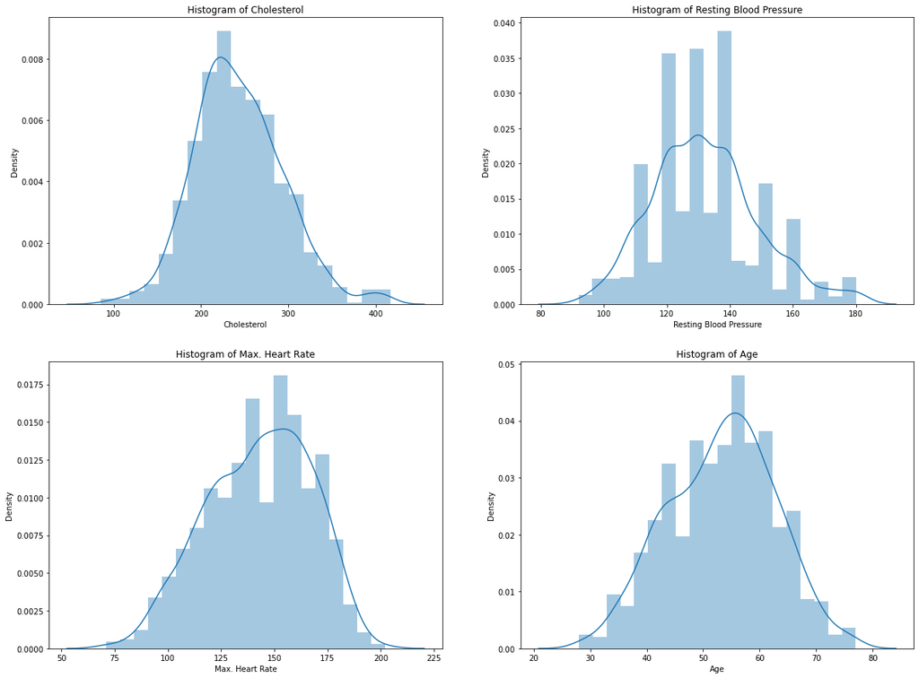

```python
plt.figure(figsize=(20,15))

plt.subplot(2,2,1)
c = sns.distplot(heart['cholesterol'],
             kde=True,
             bins=20);
c.set(title='Histogram of Cholesterol',
       xlabel='Cholesterol',
       ylabel='Density');

plt.subplot(2,2,2)
rbps = sns.distplot(heart['resting bp s'],
             kde=True,
             bins=20);
rbps.set(title='Histogram of Resting Blood Pressure',
       xlabel='Resting Blood Pressure',
       ylabel='Density');

plt.subplot(2,2,3)
mhr = sns.distplot(heart['max heart rate'],
             kde=True,
             bins=20);
mhr.set(title='Histogram of Max. Heart Rate',
       xlabel='Max. Heart Rate',
       ylabel='Density');

plt.subplot(2,2,4)
a = sns.distplot(heart['age'],
             kde=True,
             bins=20);
a.set(title='Histogram of Age',
       xlabel='Age',
       ylabel='Density');
```

### Box Plots

Box plots of the numerical variables split by target were produced to analyse the potential differences. For cholesterol and resting blood pressure there was a small difference in the means of those with heart disease compared to those without heart disease. With, on average, a higher cholesterol and resting blood pressure being seen in those with heart disease. However, it was thought that this difference in the means would be larger. As expected in the Age box plot those that had heart disease were, on average, older than those without heart disease. However, unexpectedly in the Maximum Heart Rate box plot those with heart disease exhibited, on average, a lower maximum heart rate than those without heart disease. This will be investigated further. Lastly, it can be seen in the oldpeak box plot that those with heart disease exhibited a higher average Oldpeak score than those without heart disease.

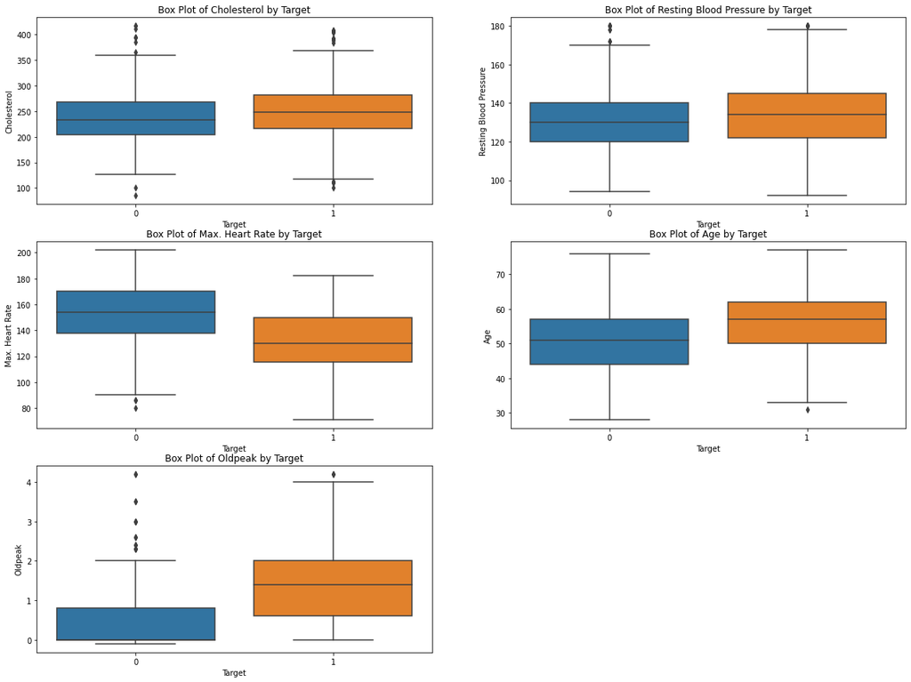

```python
plt.figure(figsize=(20,15))

plt.subplot(3,2,1)
bpc=sns.boxplot(x="target",
               y="cholesterol",
               data=heart);
bpc.set(title='Box Plot of Cholesterol by Target',
         xlabel='Target',
         ylabel='Cholesterol');

plt.subplot(3,2,2)
bprbps=sns.boxplot(x="target",
               y="resting bp s",
               data=heart);
bprbps.set(title='Box Plot of Resting Blood Pressure by Target',
           xlabel='Target',
           ylabel='Resting Blood Pressure');

plt.subplot(3,2,3)
bpmhr=sns.boxplot(x="target",
               y="max heart rate",
               data=heart);
bpmhr.set(title='Box Plot of Max. Heart Rate by Target',
          xlabel='Target',
          ylabel='Max. Heart Rate');

plt.subplot(3,2,4)
bpa=sns.boxplot(x="target",
               y="age",
               data=heart);
bpa.set(title='Box Plot of Age by Target',
        xlabel='Target',
        ylabel='Age');

plt.subplot(3,2,5)
bpo = sns.boxplot(x = "target",
                  y = "oldpeak",
                  data = heart);
bpo.set(title = 'Box Plot of Oldpeak by Target',
        xlabel = 'Target',
        ylabel = 'Oldpeak');
```

### Scatter Plots

Scatter plots were produced to see the relationship between age and cholesterol, resting blood pressure, and maximum heart rate, split by the target. The relationship between age and cholesterol, and age and resting blood pressure were uninformative. However, when examining the relationship between age and maximum heart rate a downward trend can be seen. Therefore, as age increases maximum heart rate decreases. This plot also explains why those with a lower maximum heart rate more likely to suffer from heart disease as those who have a lower maximum heart rate are typically older. Therefore, potentially age is a more influential factor than maximum heart rate for heart disease.

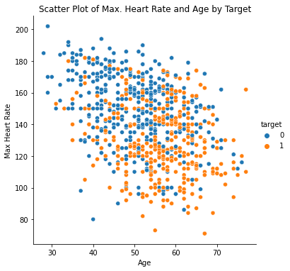

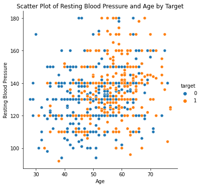

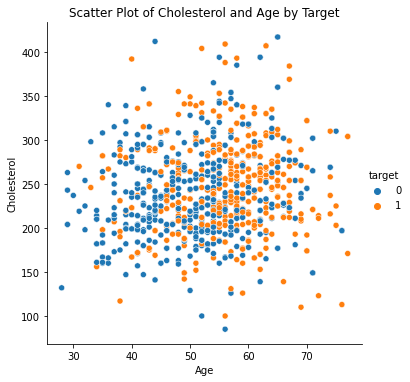

```python
amhr = sns.relplot(x="age",
            y="max heart rate",
            hue="target",
            data=heart)
amhr.set(title='Scatter Plot of Max. Heart Rate and Age by Target',
         xlabel='Age',
         ylabel='Max Heart Rate')

arbps = sns.relplot(x="age",
            y="resting bp s",
            hue="target",
            data=heart)
arbps.set(title='Scatter Plot of Resting Blood Pressure and Age by Target',
          xlabel='Age',
          ylabel='Resting Blood Pressure')

ac = sns.relplot(x="age",
            y="cholesterol",
            hue="target",
            data=heart)
ac.set(title='Scatter Plot of Cholesterol and Age by Target',
       xlabel='Age',
       ylabel='Cholesterol')
```

### Heatmap

A heatmap was produced to examine the correlations between the numerical features and the target. Moderate correlations were found between maximum heart rate, oldpeak, age and the target variable. Furthermore, moderate negative correlations were found between age and maximum heart rate, and maximum heart rate and oldpeak.

```
[Text(0.5, 1.0, 'Heatmap of Numerical Variables and Target')]
```

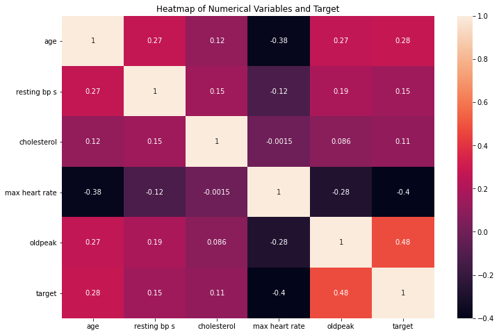

```python
plt.figure(figsize=(12,8))
hm = sns.heatmap(heart.corr(), annot=True)
hm.set(title='Heatmap of Numerical Variables and Target')
```

### Bar Plots

Some of the categorical variables were examined using Bar Plots. When looking at the chest pain type plot a large amount of those with heart disease tended to be males with an asymptomatic chest pain type. A similar picture can be seen when looking at exercise induced angina and ST slope. A large amount of those with heart disease being males who have exercise induced angina and for ST slope males who exhibit a flat value. Furthermore, those without heart disease typically did not have exercise induced angina across both genders and an up-sloping ST slope.

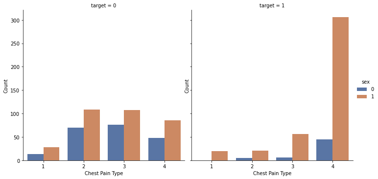

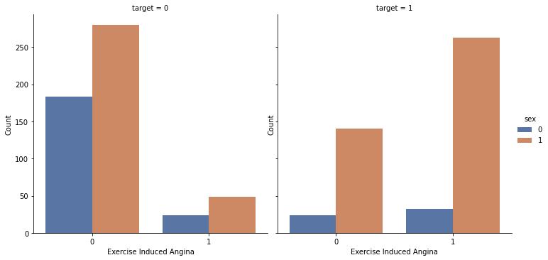

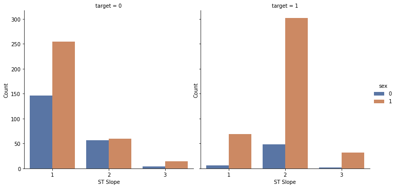

```python
plt.figure(figsize=(20,15))

cpchest=sns.catplot(x="chest pain type", kind ="count", hue = "sex", palette= 'deep', col ="target", data=heart)
cpchest.set(xlabel='Chest Pain Type',
            ylabel='Count');

cpea = sns.catplot(x = 'exercise angina', kind = 'count', hue  = 'sex', palette = 'deep', col = 'target', data = heart)
cpea.set(xlabel='Exercise Induced Angina',
         ylabel='Count');

cpST = sns.catplot(x = 'ST slope', kind = 'count', hue = 'sex', palette = 'deep', col = 'target', data = heart)
cpST.set(xlabel='ST Slope',
         ylabel='Count');
```

### Multi-Variable Box Plots

After seeing the large difference in the means of oldpeak by the target variable, oldpeak was analysed further. Analysing the multi-variable box plots, it is clear that the median oldpeak measurement, an indicator for poor heart health (i.e., ischemia) is higher in the heart disease group for patients with prior history of exercise angina and an ST slope of 3.

An ST slope of 3 indicates a down-sloping ST segment on an electrocardiogram (ECG) which is a common indicator of severe myocardial ischemia.

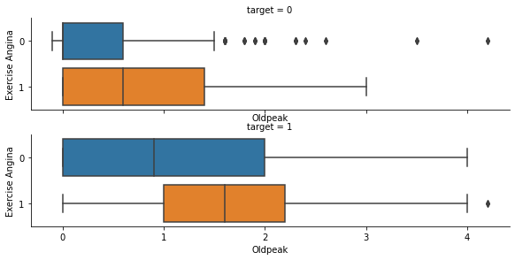

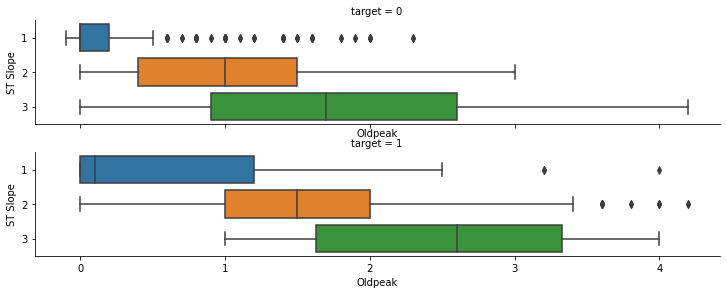

```python
cpeao = sns.catplot(y="exercise angina", x="oldpeak", row="target",
                kind="box", orient="h", height=2, aspect=4,
                data=heart)
cpeao.set(xlabel='Oldpeak',
            ylabel='Exercise Angina');

cpsto = sns.catplot(y="ST slope", x="oldpeak", row="target",
                kind="box", orient="h", height=2, aspect=5,
                data=heart)
cpsto.set(xlabel='Oldpeak',
            ylabel='ST Slope');
```

## Further Preprocessing

### Converting the Target variable to a categorical variable

The Target variable was read in as a numerical variable when it is categorical in nature. Therefore, it is converted into a categorical variable below. The reason it was not converted earlier is because the correlations between the numerical variables and the target variable were to be examined in this report.

```python
heart['target']=heart['target'].astype('object')
```

```python
heart['target'].unique()
```

```
array([0, 1], dtype=object)
```

## Conclusion

The purpose of Phase 1 was to prepare and explore the Heart Disease dataset for machine learning. In order to do so, we needed to develop a strong understanding of the data, the existing relationships between variables and the key features related to the target variable.

The key takeaway from our analysis is that old age, higher oldpeak measurements, presence of exercise angina, asymptomatic chest pain and an ST Slope reading of 2 (flat) or 3 (downward sloping) was more pronounced in patients with heart disease compared to patients without heart disease.

Looking forward to Phase 2, some of the aforementioned variables identified will be instrumental for feature selection purposes.

## References

- “What Is up Sloping ST Depression ? How Do You Measure It ? What Is the Clinical Significance ?” Dr.S.Venkatesan MD, 27 Sept. 2009, drsvenkatesan.com/2009/09/04/what-is-upsloping-st-depression-how-do-you-measure-it-what-is-the-clinical-significance/.
- “Why Does Maximum Heart Rate Drop with Age?” ScienceDaily, ScienceDaily, 14 Oct. 2013, www.sciencedaily.com/releases/2013/10/131014155744.htm.
- Sharma, N. (2018). Ways to Detect and Remove the Outliers. Retrieved 9 April 2021, from https://towardsdatascience.com/ways-to-detect-and-remove-the-outliers-404d16608dba